# 1 Introduction

- Show All Code
- Hide All Code

Lecture 1: Introduction to Math5485

Published

September 9, 2026

Overview

1. Syllabus, Canvas, website, and admin;
2. Intro to notebooks;
3. Overview of Math5485;
4. Intro to Numerical Analysis;
5. Exercises

**Warning**

These lecture notes are mainly a record of what we discussed in class. They should not be used as a replacement for attending lectures or reading books. Please let me know if you find any errors or have any questions about the material.

**TipHypothesis**

You can use the Hypothesis commenting system available on the right side panel (you can login with your U/Google account). This allows you annotate the notes (private) and leave comments or reply to other people’s comments (public).

**Note**

I encourage you to download the lecture notes and play around with the Julia code.

Download (.ipynb) Ask a Question [ChimeIn](https://chimein.cla.umn.edu/join/330276)

## 1.1 Notebooks

This website is created using Jupyter Notebooks. They allow you to include Markdown, $\LaTeX$, and Julia (as well as python and other languages).

**Tip**

Follow the steps in installing-julia.html and A1 to learn about notebooks and Julia.

Notebooks are made up from “cells”.

- `A` adds a cell above the currently selected cell,
- `B` adds a cell below,
- `M` changes the cell from Julia to markdown,
- `Y` changes the cell from markdown to Julia,
- Double click or `enter` to see the syntax and edit cells,
- Press `ctrl`+`enter` to exit edit mode,

**Exercise 1.1** Add a new markdown cell below this one and write “Hello world!”

## 1.2 Markdown

Text in this cell can be **bold**, *italic*, *bold italic*, quotes

> “The only source of knowledge is experience”  
> – Einstein

```
Preformatted text,
    useful for
pseudocode
```

- Bullet points
  - level 2 bullet points
  - etc..
- Another point

You can also use normal html formatting if you are familiar with that…

Markdown cheat sheet: [link](https://www.markdownguide.org/basic-syntax/)

## 1.3 $\LaTeX$

$\LaTeX$ allows you to display math: e.g. $\pi \approx \frac{22}{7}$ and
$$f(x) = f(a) + f'(a) (x - a) + \frac{1}{2} f''(a) (x-a)^2 + R(x).$$

Multi-line equations are also possible:

$$\begin{align}
\int_a^b f(x) \mathrm{d}x
%
&\approx \int_a^b p_n(x) \mathrm{d}x \nonumber \\
%
&= \sum_{j=0}^n w_j f(x_j)
\end{align}
\tag{1.1}$$

$\LaTeX$ cheat sheet: [link](https://quickref.me/latex.html)

Draw symbol to get $\LaTeX$ syntax: [link](https://detexify.kirelabs.org/classify.html)

## 1.4 Julia

```julia
1+1
```

```
2
```

You can use greek symbols in Julia code: type `\pi` and `tab` to get the symbol.

```julia
π
```

```
π = 3.1415926535897...
```

You can add comments with a `#`:

```julia
# Define p
p = 22/7;
```

You can also use `@show` to print variables (which also prints the calculation):

```julia
@show abs(π-p)/π;
```

You can use `println()` to output variables (and you can also add text):

```julia
println( "The relative error when approximating π by 22/7 is ", abs(π-p)/π)
```

```
abs(π - p) / π = 0.0004024994347707008
The relative error when approximating π by 22/7 is 0.0004024994347707008
```

### 1.4.1 Arrays, vectors, and matrices

Arrays start at 1:

```julia
a = [1 2 3 4 5]
```

```
1×5 Matrix{Int64}:
 1  2  3  4  5
```

```julia
a[1]
```

```
1
```

Vectors:

```julia
b = [2, 4, 6, 8]
```

```
4-element Vector{Int64}:
 2
 4
 6
 8
```

Vector of objects:

```julia
c = [ a , b , "hello world" ]
```

```
3-element Vector{Any}:
 [1 2 … 4 5]
 [2, 4, 6, 8]
 "hello world"
```

```julia
c[3]
```

```
"hello world"
```

Matrices

You can either specify the columns:

```julia
X = [ [1, 4] [2, 5] ]
```

```
2×2 Matrix{Int64}:
 1  2
 4  5
```

Or the rows:

```julia
Y = [ 1 2 ; 4 5 ]
```

```
2×2 Matrix{Int64}:
 1  2
 4  5
```

### Linear Algebra

In order to use a certain package, you need to use the `using` keyword:

```julia
using LinearAlgebra
```

Recall that

```julia
X
```

```
2×2 Matrix{Int64}:
 1  2
 4  5
```

```julia
det( X )
```

```
-3.0
```

```julia
tr( X )
```

```
6
```

```julia
(-1/3) * [ 5 -2 ; -4 1 ]
```

```
2×2 Matrix{Float64}:
 -1.66667   0.666667
  1.33333  -0.333333
```

```julia
inv( X )
```

```
2×2 Matrix{Float64}:
 -1.66667   0.666667
  1.33333  -0.333333
```

```julia
ϵ, v = eigen( X )
```

```
Eigen{Float64, Float64, Matrix{Float64}, Vector{Float64}}
values:
2-element Vector{Float64}:
 -0.4641016151377544
  6.464101615137754
vectors:
2×2 Matrix{Float64}:
 -0.806898  -0.343724
  0.59069   -0.939071
```

```julia
v1 = v[1:2,1]; # gets the first column of v
norm( ( X - ϵ[1] * Diagonal([1, 1]) ) * v1 )
```

```
2.220446049250313e-16
```

### 1.4.2 Functions

```julia
f = x -> cos( x );
f( π )
```

```
-1.0
```

```julia
# vectorisation = entry-wise functuions --> use dot!
f.( [-π, 0, π] )
```

```
3-element Vector{Float64}:
 -1.0
  1.0
 -1.0
```

```julia
# you can also specify the vectorisation at the start:
@. f( [-π, 0, π] )
```

```
3-element Vector{Float64}:
 -1.0
  1.0
 -1.0
```

In order to plot functions we need the `Plots` package and, in order to write $\LaTeX$ in the titles and labels, we need `LaTeXStrings`.

```julia
using Plots, LaTeXStrings
```

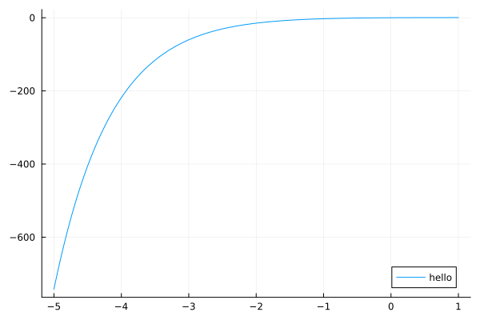

```julia
g(x) = x/exp(x)
plot( g, -5, 1, label="hello" )
```

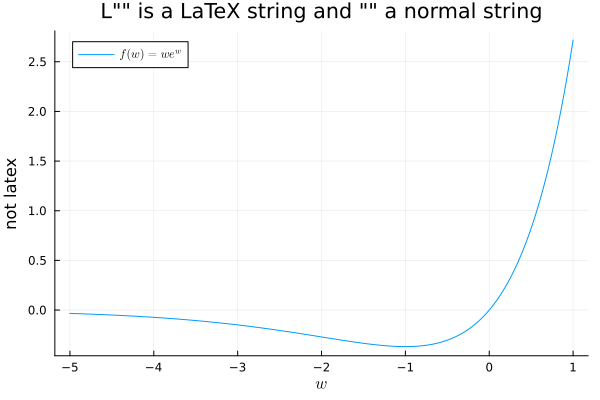

```julia
X = -5:.01:1;
Y = X .* exp.(X) ;

plot( X, Y;
    label = L"f(w) = w e^w",
    xlabel = L"w", ylabel = "not latex",
    title = "L\"\" is a LaTeX string and \"\" a normal string" )
```

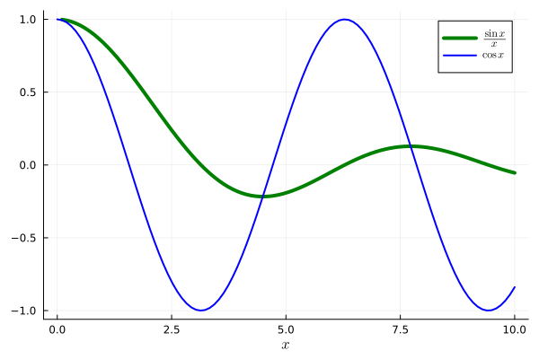

Figure 1.1: Ploting two functions on one graph

```julia
X = range(0, 10, length=100)
Y1 = @. sin(X) / X
Y2 = cos.(X)
plot( X, [Y1 Y2],
        xlabel=L"x",
        label=[L"\frac{\sin x}{x}" L"\cos x"],
        linewidth=[4 2],
        lc=[:green :blue])
```

In Figure 1.1, you can see two graphs!

**Note**

If you are looking at the code, don’t worry about the `@fig-1` or the `::: {.callout-note}` syntax - this adds the html/css elements so that the webpage looks nicer.

`!` is like “hold on” in Matlab (if you are familar with that!)

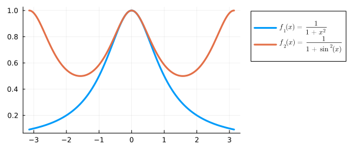

Figure 1.2: Ploting functions

```julia
f3(x) = 1 / (1 + x^2);
f4(x) = 1 / (1 + sin(x)^2);
plot(f3, -π, π,
        lw=3,
        label = L"f_1(x) = \frac{1}{1+x^2}");
plot!(f4, -π, π,
        lw = 3,
        label = L"f_2(x) = \frac{1}{1+\sin^2(x)}",
        size = (600, 250), legend = :outertopright )
```

## 1.5 Math 5485

- Chapter 1: Basics of Numerical Analysis
- Chapter 2: Solving Nonlinear Equations in 1d
- Chapter 3: Polynomial Interpolation
- Chapter 4: Numerical Integration
- Chapter 5: Linear systems of equations

## 1.6 Chapter 1: Basics of Numerical Analysis

- Absolute and relative error
- Rate of convergence
- Using plots to show rate of convergence

Suppose we approximate $x$ with $\widetilde{x}$. Here, $x$ could be e.g. a root (or fixed point) of a function, the value of an integral, the solution of an ODE or PDE evaluated at a point, …. .

**Definition 1.1 (Errors)** We define:

$$\begin{align}
\text{Actual error:} &\quad x - \widetilde{x} \\
\text{Absolute error:} &\quad |x - \widetilde{x}|
\end{align}$$

And when $x \neq 0$, the relative error is:

$$\begin{align}
\text{Relative error:} \quad \frac{|x - \widetilde{x}|}{|x|}
\end{align}$$

**Example 1.1** If $x = 1.5$ and $\widetilde{x} = 1$, then the absolute error is $0.5$ and the relative error is $\frac{0.5}{1.5} = \frac13$.

If $x = 1.5 \times 10^{42}$ and $\widetilde{x} = 10^{42}$, then the absolute error is $0.5 \times 10^{42}$ and the relative error is $\frac13$.

If $x = 1.5 \times 10^{-42}$ and $\widetilde{x} = 10^{-42}$, then the absolute error is $0.5 \times 10^{-42}$ and the relative error is $\frac13$.

The relative error is a better measure for small or large $x$:

**Example 1.2** Approximating Planck’s constant $6.62607015 \times 10^{-34} \text{m}^2 \text{kg } \text{s}^{-1}$ with $0 \text{m}^2 \text{kg } \text{s}^{-1}$ would give an absolute error of $\approx 6 \times 10^{-34}$ (which seems small) but a relative error of $1$. In practice $0$ is a bad approximation to Planck’s constant!

**Definition 1.2 (Number of correct significant digits)** Suppose $x \not= 0$ is approximated by $\widetilde{x}$. Then, we say this approximation is accurate to $n$ significant digits if

$$\left| \frac{x-\widetilde{x}}{x} \right| \leq 5 \times 10^{-n}.$$

**Example 1.3** Approximating $e := \lim_{n\to\infty} \big( 1 + \frac1n \big)^n \approx 2.7182818.....$ with $3, 2.7,$ and $2.718$ gives

$$\begin{align}
\left| \frac{e-\widetilde{x}}{e} \right| = 1.04 \times 10^{-1}, \quad 0.673 \times 10^{-2}, \quad 0.104 \times 10^{-3},
\end{align}$$

respectively.

```julia
e = exp(1)
abs( (e-3)/e ), abs( (e-2.7)/e ), abs( (e-2.718)/e )
```

```
(0.10363832351432703, 0.006725508837105614, 0.00010367889601972718)
```

*Remark 1.1* (Number of correct significant digits). Suppose $x \not= 0$ is approximated by $\widetilde{x}$. Some people say that this approximation is accurate to

$$\eta := - \log_{10} \left| \frac{x-\widetilde{x}}{x} \right|$$

significant digits.

**Exercise 1.2** Compute $\eta$ for approximating $e$ with $3$, $2.7$, and $2.718$.

We now consider a sequence of approximations $x_n$ converging to $x$. That is, for all $\varepsilon > 0$, there exists $N=N(\varepsilon)$ such that $|x - x_n| < \varepsilon$ for all $n > N$. In numerical analysis, we are interested in *(i)* whether our numerical schemes converge, and *(ii)* the rate of convergence:

**Definition 1.3 (Rate of convergence)** Suppose $\varepsilon_n \geq 0$ and $(\varepsilon_n) \to 0$. Then, $x_n \to x$ with rate $O(\varepsilon_n)$ if there exist $C$ and $N$ such that

$$|x - x_n| \leq C\varepsilon_n$$

for all $n > N$. We also write $x_n = x + O(\varepsilon_n)$.

**Exercise 1.3** Show that $\frac{n + \cos(n)}{n^2} = O(\frac1n)$ and $\frac{n^2+3}{n^{42}} = O(\frac1{n^{40}})$.

When plotting graphs, $O(n^{-k})$ decay (that is, **algebraic** decay) can be seen as straight lines on log-log plots ($-k$ is the slope in such graphs):

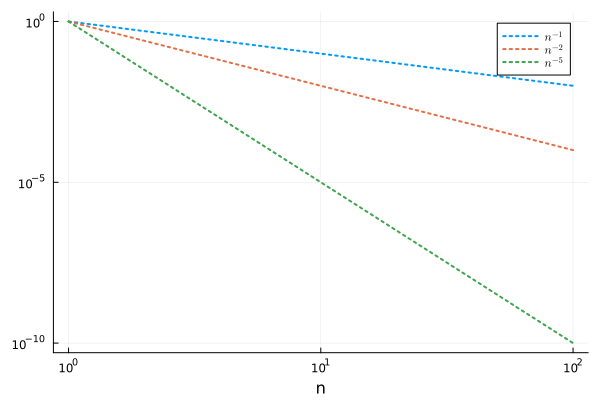

```julia
N = 1:100;
plot( N.^(-1) ;
    xlabel="n", xaxis=:log, yaxis=:log,
    linestyle = :dot, lw=2, label = L"n^{-1}")
plot!( N.^(-2);
    linestyle = :dot, lw=2, label = L"n^{-2}")
plot!( N.^(-5);
    linestyle = :dot, lw=2, label = L"n^{-5}")
```

On the other hand, $O(e^{-c N})$ (that is, **exponential** decay) can be seen as straight lines on a semi-log y plot (and $-c$ is the gradient):

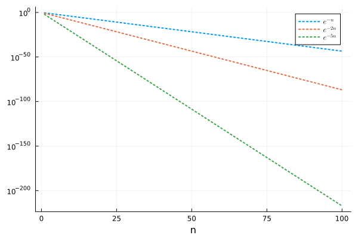

```julia
plot( exp.(-N);
    xlabel="n", yaxis=:log,
    linestyle = :dot, lw=2, label = L"e^{-n}")
plot!( exp.(-2 .* N );
    linestyle = :dot, lw=2, label = L"e^{-2n}")
plot!( exp.(-5 .* N );
    linestyle = :dot, lw=2, label = L"e^{-5n}")
```

**TipTO-DO**

- Assignment 1: Due Wednesday (Install Julia),
- Exercises (below)
- (Sign-up to office hours if you like)

## 1.7 Exercises

**Exercise 1.4** Let $e$ denote Euler’s constant.

1. $e_N := \big( 1 + \frac{1}{N} \big)^N$ is an approximation $e$. What is the error, absolute error, and relative error in approximating $e$ with $e_N$ for $N = 1,2,...,10$? What are the number of accurate digits in this approximation?
2. What is the rate of convergence of $e_N$ to $e$?

**TipSolution**

Answers will be avaliable here one week after the lecture. Please try yourself first!

**Exercise 1.5** Euler-Mascheroni constant, $\gamma$, is defined as the limit of $\gamma_n = \sum_{k=1}^n \frac{1}{k} - \log n$ as $n \to \infty$.

1. What is the absolute error in approximating $\gamma$ with $\gamma_{1000}$?
2. What is the rate of convergence of $\gamma_n$ to $\gamma$?
3. [This was just so that we can remember some calculus and also rigorously prove the rate of convergence that we have seen above using a rigorous error estimate]  
   Prove that $|\gamma - \gamma_n| \leq \frac1n$.

**TipSolution**

Answers will be avaliable here one week after the lecture. Please try yourself first!

**Exercise 1.6** *Assignment 1, Fall 2025, [30 pts]* The quantities

$$\begin{align}
\pi_N := 4 \sum_{n=0}^N \frac{(-1)^n}{2n+1}
\end{align}$$

approximate $\pi$ by using the Taylor expansion of $\arctan$ together with the fact that $\pi = 4 \arctan(1)$.

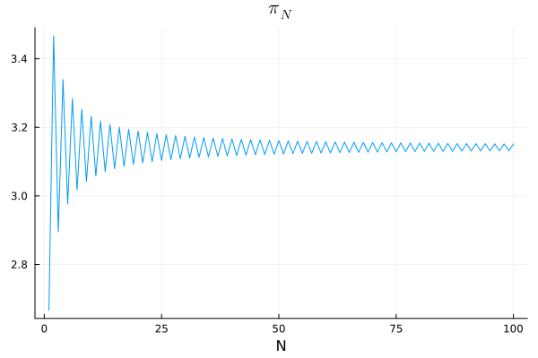

```julia
using Plots, LaTeXStrings

Nmax = 100;
Ninter = 1:Nmax;

# vectors of length Nmax
p = zeros( Nmax ); q = zeros( Nmax );
p[1] = 4 * ( 1 - 1/3 ) ;
q[1] = abs( p[1] - π );
for N in 2:Nmax
    p[N] = p[N-1] + 4 * (-1)^N/(2*N + 1);
    q[N] = abs( p[N] - π );
end

plot(p, legend=false, xlabel="N", title=L"\pi_N")
```

Based on the following graph, what is the rate of convergence of this particular approximation to $\pi$? Why do we use a log-log scale for this graph?

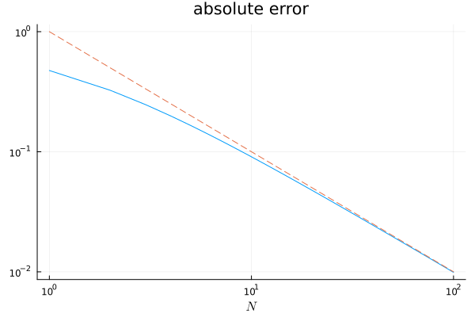

```julia
plot( q , xaxis=:log, yaxis=:log, xlabel=L"N", title="absolute error", legend=false)
plot!( Ninter.^(-1) , ls=:dash)
```